# Mortality after vaccination

Anonymous

29/09/2021

## Data

This report is based on VAERS database (https://vaers.hhs.gov/data.html) with the last record on the 23 Jul 2021.

VAERS database contains records about side effects from various vaccines. The database is run from year 1990. Some side effects are deaths of the patients. The database contains records about 16784 deaths.

Every vaccine applied to many patients with high probability will have death records in the VAERS database. This is because that even if the source of the death is not determined exactly but the vaccine could contribute to the death of the patient, the corresponding record would appear in the database.

## Comparison of the vaccines using mortality after vaccination

There are multiple ways to compare safety of different vaccines. Probably one of the most robust ways is to calculate probability to die after the vaccine shots for comparable age groups. The higher probability to die after the shot the less safe is the vaccine.

Since at this stage of the reserch the whole number of vaccine shots is not available for all vaccines, it is difficult to calculate probability of death after the shot of a particular vaccine. Although, what is possible is to use number of simple cases as a proxy for number of administered vaccine shots.

To separate age groups with extreme mortality rates (naturally) we consider age groups from 18 to 60, and from 61. Also, only records from 2010 are taken into account. Records with unknown vaccines or vaccine manufacturers are excluded as well.

Two types of vaccines are considered: “COVID-19” vaccines and “ALL OTHERS”. In the graph below we consider ratio of all deaths after a particular vaccine. The data is split by vaccine or vaccine manufacturer and colored by vaccine type. Groups with small number or observations (less than 100) are excluded from the graphs.

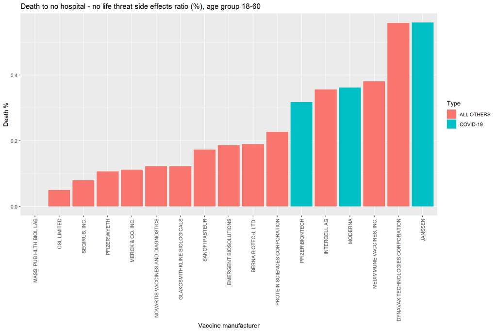

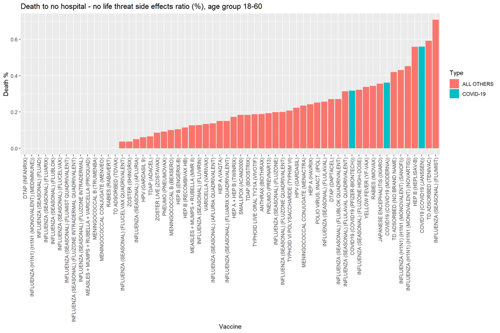

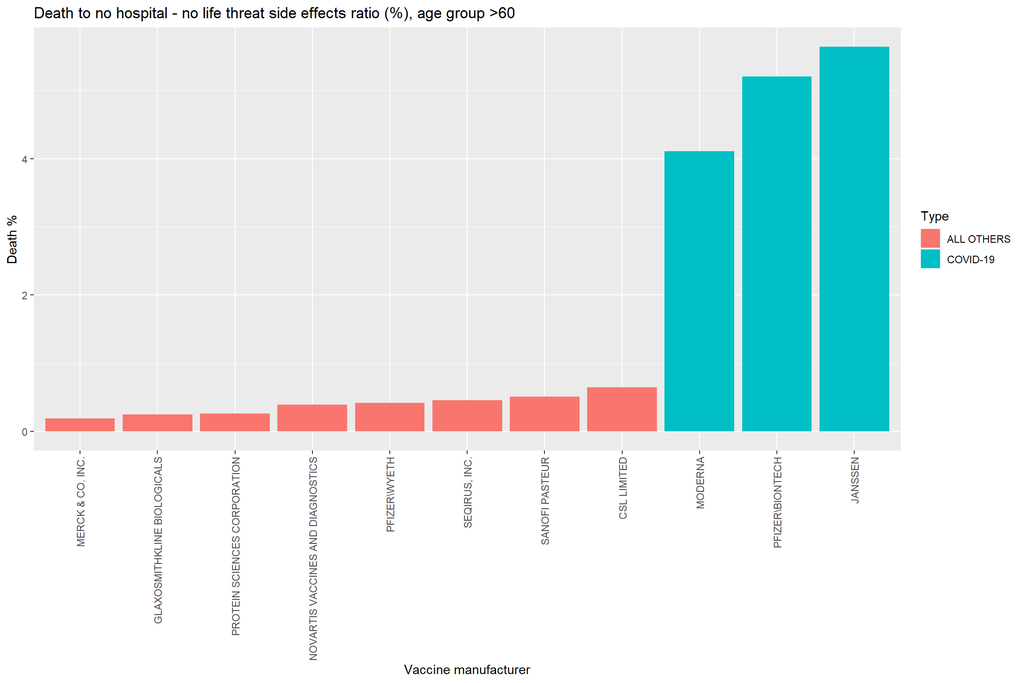

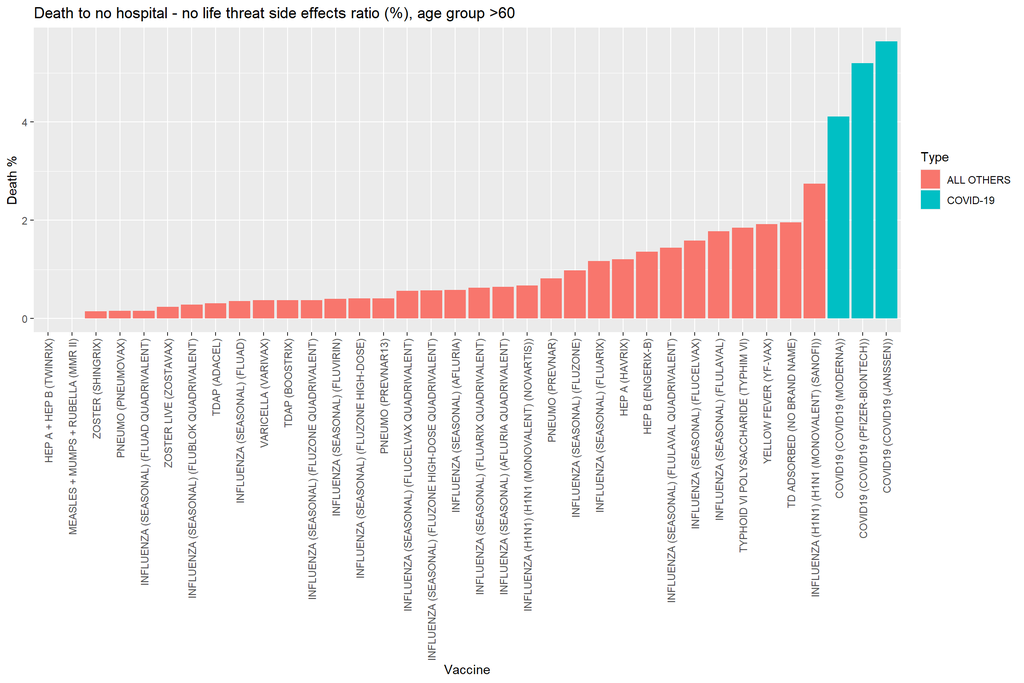

As we can see mortality rates are high for age group from 61.

Another way is to compare hospitalized patiens who survived and who died. It is more reliable way to compare as “light” cases can be under-reported because of various reasons.

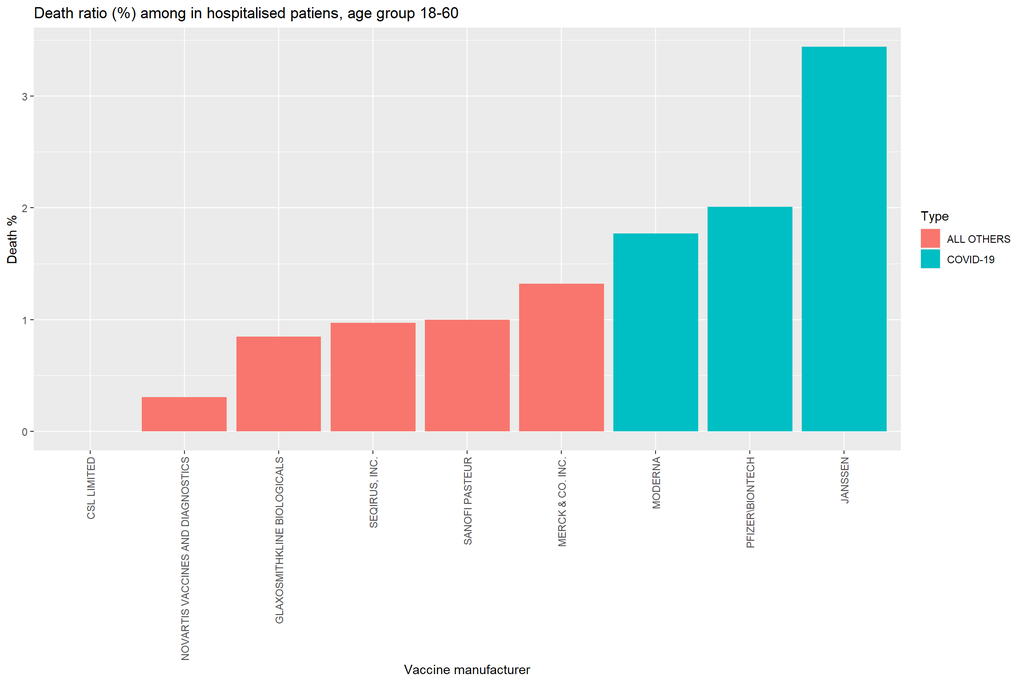

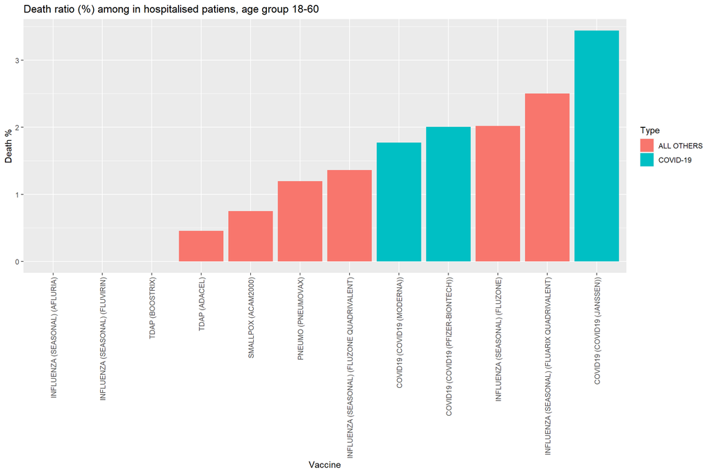

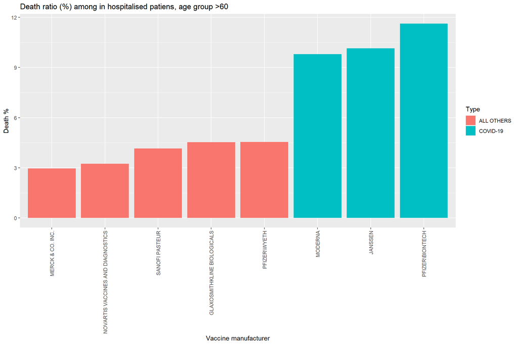

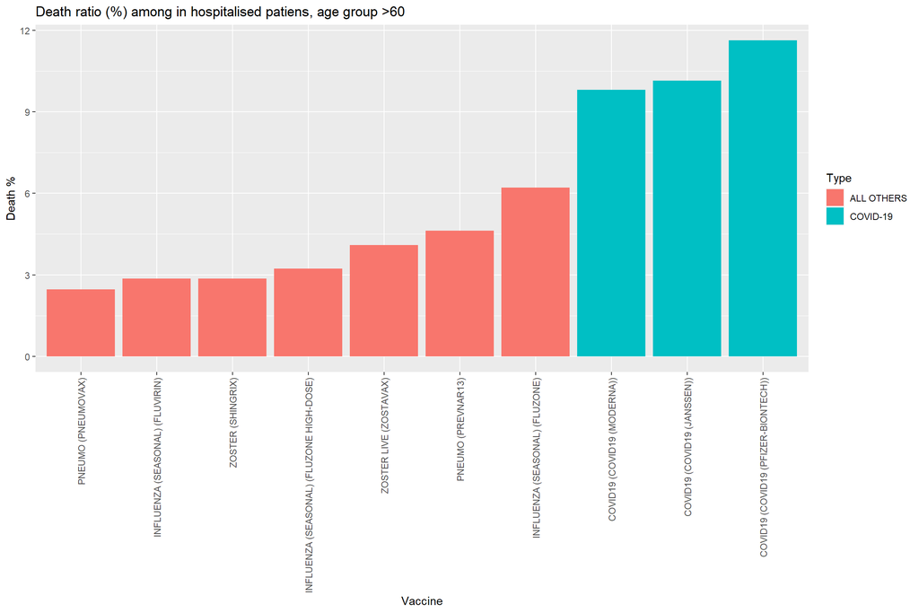